# Blue whiting HCR Evaluation

## Assessment Error

The assessment error can be evaluated by performing a retrospective analysis and comparing the difference between the most recent stock assessment and those conducted with the same data in previous years.

```r
drop_download(path='bluewhiting/data/retro.RData',local_path="data",overwrite=TRUE)

load(file.path("data","retro.RData"))
```

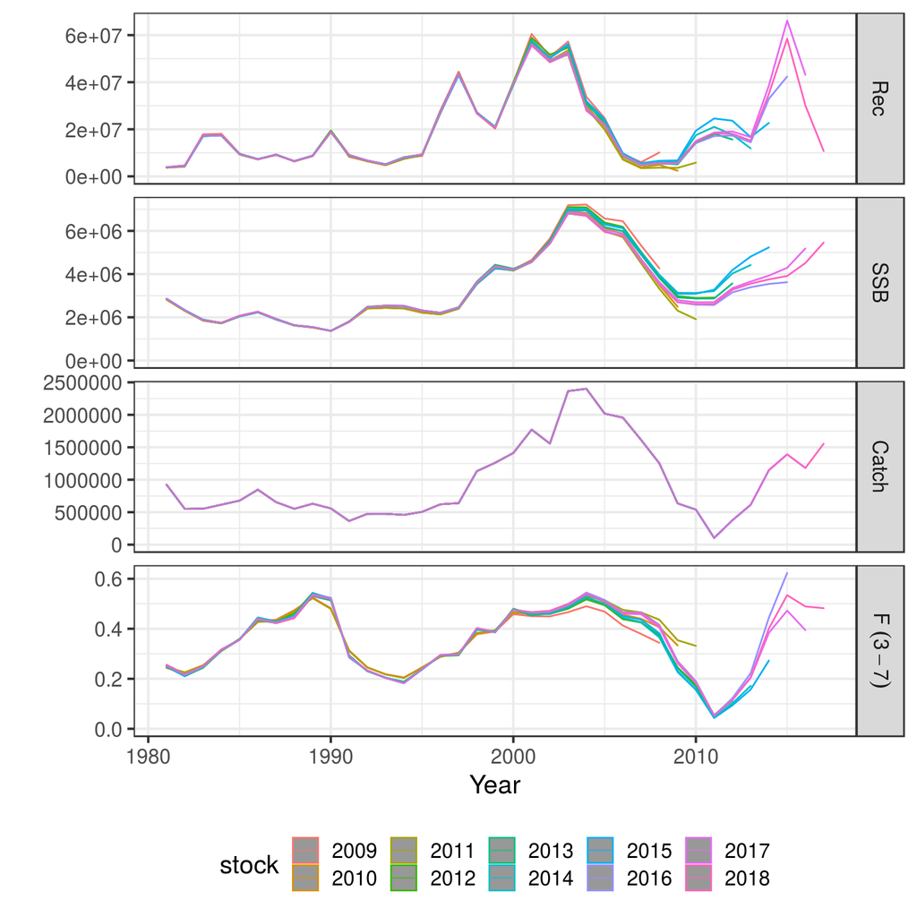

```r
plot(retro)+
  theme_bw(16)+
  theme(legend.position="bottom")+
  xlab("Year")
```

**Figure 12** Retrospective analysis.

```r
assEr=laply(retro, function(x){
  yr=ac(dims(fbar(x))$maxyear)

  c(f  =c(catch(x  )[,yr]/computeStock(x  )[,yr])/
        c(catch(om1)[,yr]/computeStock(om1)[,yr]),
    ssb=c(ssb(x)[,yr])/c(ssb(om1)[,yr]))})
```

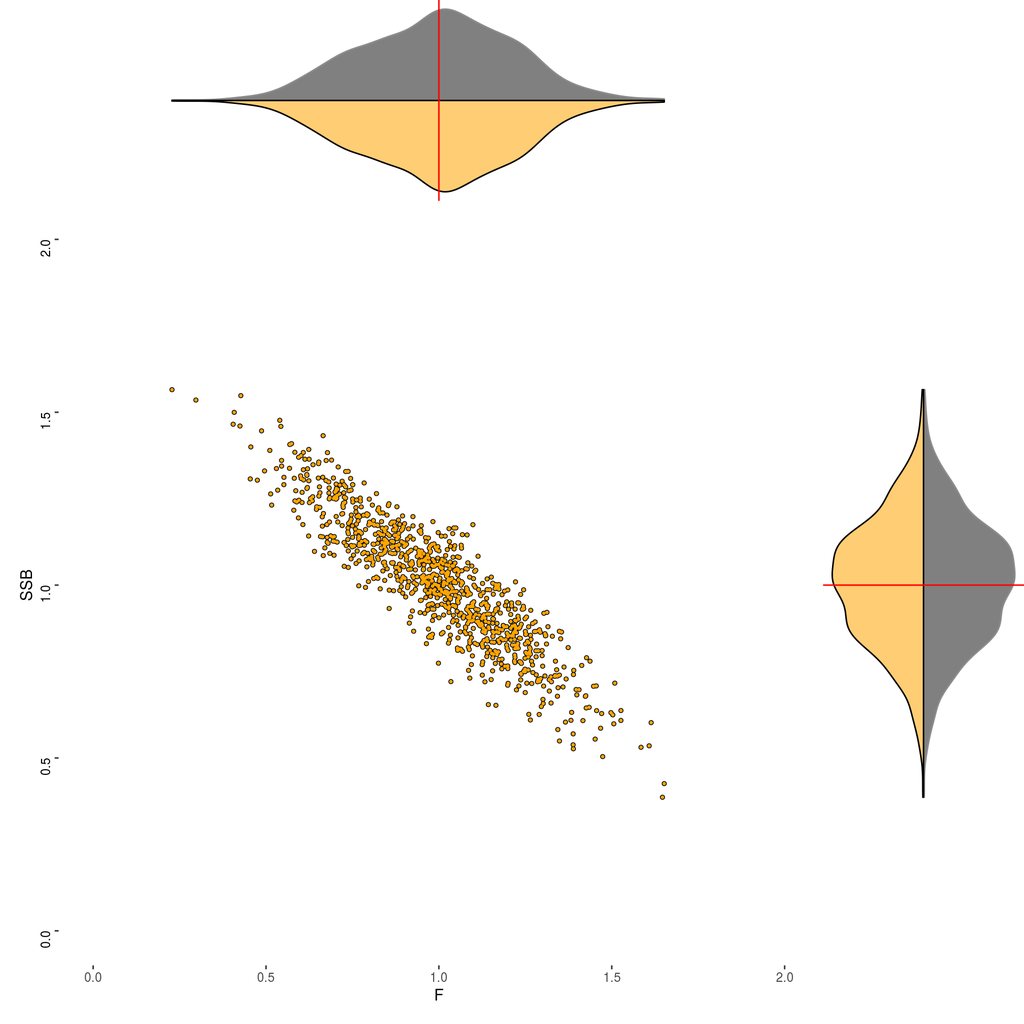

```r
library(grid)
source('/home/laurence/Desktop/flr/kobe/R/kobe-phaseMar.R')
source('/home/laurence/Desktop/flr/kobe/R/kobe-phase.R')

dt2=as.data.frame(rmvnorm(1000,c(1,1),cov(assEr)))

names(dt2)=c("stock","harvest")

kobePhaseMar(dt2,quadcol=c("white","white","white","white"),
  xlab="F",ylab="SSB")
```

**Figure 13** Simulation of assessment error based on retrospective analysis.

# Simulations

The objects to run the simulations are now available, i.e. om the ‘FLStock’ object, eql the ‘FLBRP’ object with the stock recruitment relationship.

Just make sure all objects have enough iters to hold outputs.

```r
om=propagate(om,1000)
```

The ICES reference points and HCR parameters are then loaded as ‘FLPar’ objects.

```r
### ICES reference points
refpts=FLPar(c(
  blim    =1500000,
  bpa     =2250000,
  flim    =0.88,
  fpa     =0.53,
  msytrig =2250000,
  fmsy    =0.32,
  bmgtlow =1500000,
  bmgt    =2250000,
  fmgstlow=0.05,
  fmgt    =0.32),units="NA")
```

```r
par1=array(c(ftar=refpts["fmsy"],btrig=refpts["msytrig"],fmin=FLPar(0.05),blim=refpts["blim"]),
           dim=c(4),
           dimnames=list(c("ftar","btrig","fmin","blim")))
par1
```

```
    ftar    btrig     fmin     blim
3.20e-01 2.25e+06 5.00e-02 1.50e+06
```

```r
par2=array(c(0.20,2250000,
             0.05,1500000,
             0.32,5200000,
             0.20,4000000),
          dim=c(4,2),
          dimnames=list(c("ftar","btrig","fmin","blim"),c("lower","upper")))[c(1,3,2,4),1:2]

par2
```

```
         lower   upper
ftar  2.00e-01 3.2e-01
fmin  5.00e-02 2.0e-01
btrig 2.25e+06 5.2e+06
blim  1.50e+06 4.0e+06
```

First run a simple projection for $F_{MSY}$ for comparison with the ICES assessment and the HCR outcomes.

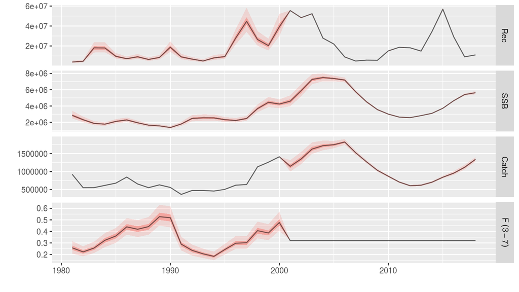

```r
fmsy=fwd(om,fbar=FLQuant(1,dimnames=list(year=2001:2018))%=%0.32,
                         sr=eql9,residuals=exp(residuals(sr9)))

plot(fmsy)
```

**Figure 14** Timeseries from $F_{MSY}$ projection.

### HCRs

Run a HCR without assessment error and compare to the projection.

```r
source('/home/laurence/Desktop/sea++/mydas/pkg/R/hcrICES.R')

HCR1NoErr=hcrICES(om,eql9,
             sr_deviances=propagate(exp(residuals(sr9)),1000),
             params=par1,
             start=2001,end=2018)
```

```
==2001, 2002, 2003, 2004, 2005, 2006, 2007, 2008, 2009, 2010, 2011, 2012, 2013, 2014, 2015, 2016, 2017, ==
```

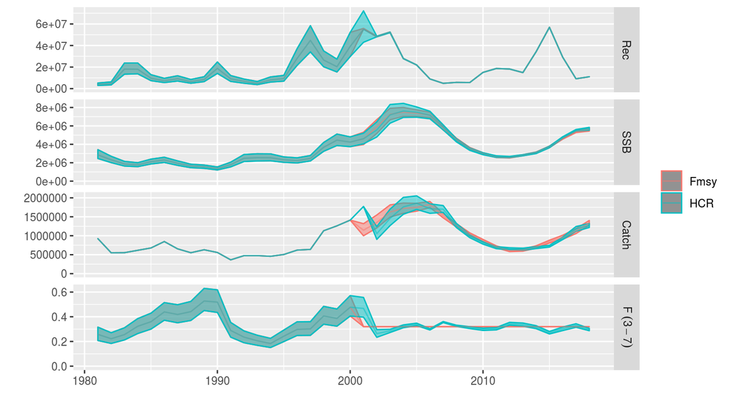

```r
plot(FLStocks("Fmsy"=fmsy,"HCR"=HCR1NoErr[[1]]))
```

**Figure 15** Comparison of timeseries for $F_{MSY}$ projection and HCR without assessment error.

Add assessment error.

```r
err =rlnorm(1000,FLQuant(0,dimnames=list(year=2000:2018)),0.3)

HCR1=hcrICES(om,eql9,
             sr_deviances=propagate(exp(residuals(sr9)),1000),
             params=par1,
             start=2001,end=2018,
             err=err)
```

```
==2001, 2002, 2003, 2004, 2005, 2006, 2007, 2008, 2009, 2010, 2011, 2012, 2013, 2014, 2015, 2016, 2017, ==
```

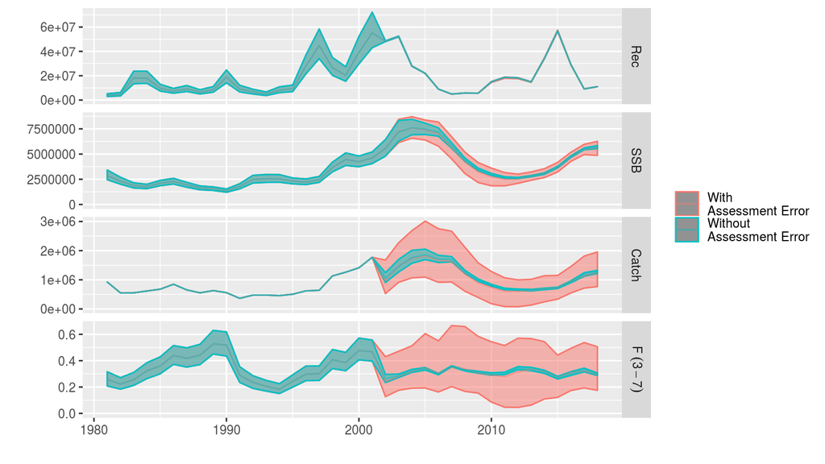

```r
plot(FLStocks("Without \nAssessment Error"=HCR1NoErr[[1]],"With \nAssessment Error"=HCR1[[1]]))
```

**Figure 16** Comparison of timeseries for HCR I with and without assessment error.

Compare the two HCRs.

```r
HCR2=hcrICES(om,eql9,
             sr_deviances=propagate(exp(residuals(sr9)),1000),
             params=par2,
             start=2001,end=2018,
             err=err)
```

```
==2001, 2002, 2003, 2004, 2005, 2006, 2007, 2008, 2009, 2010, 2011, 2012, 2013, 2014, 2015, 2016, 2017, ==
```

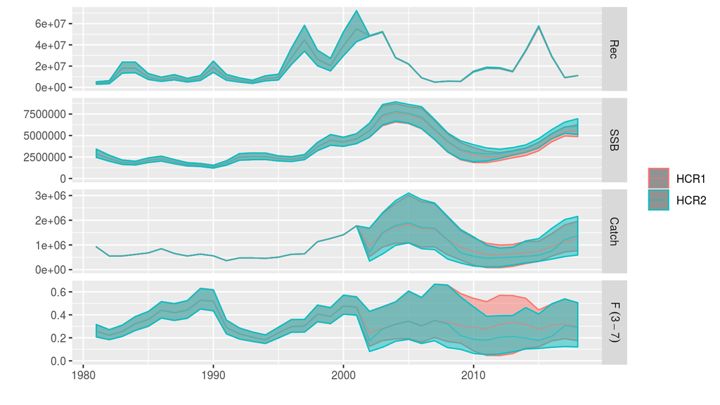

```r
plot(FLStocks("HCR1"=HCR1[[1]],"HCR2"=HCR2[[1]]))
```

**Figure 17** Comparison of timeseries for HCR I and HCR II.

Evaluate the effect of bounds.

```r
HCR1Bnd=hcrICES(om,eql9,
             sr_deviances=propagate(exp(residuals(sr9)),1000),
             params=par1,
             start=2001,end=2018,
             err=err,
             bndTac=c(0.80,1.25))
```

```
==2001, 2002, 2003, 2004, 2005, 2006, 2007, 2008, 2009, 2010, 2011, 2012, 2013, 2014, 2015, 2016, 2017, ==
```

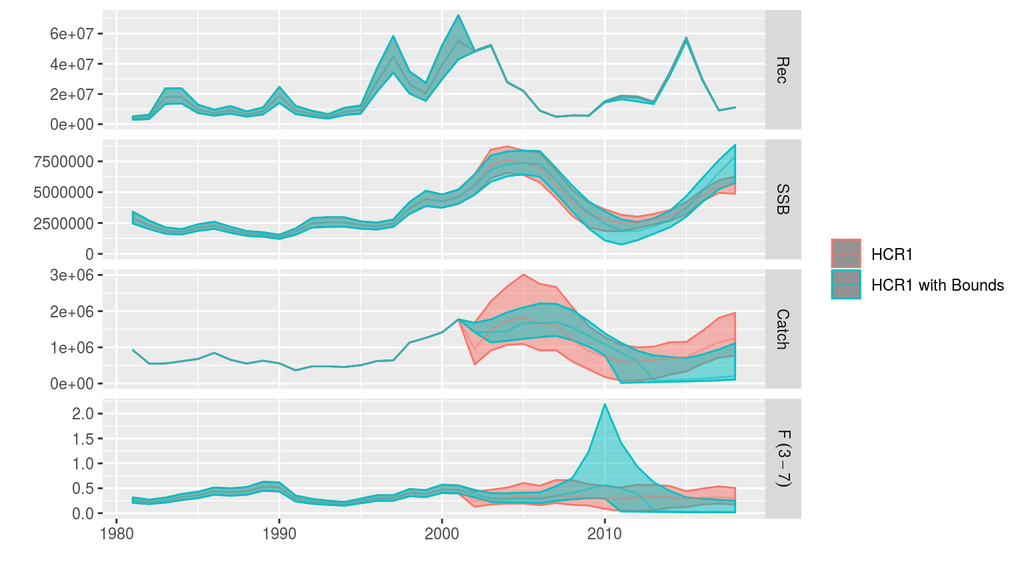

```r
plot(FLStocks("HCR1"=HCR1[[1]],"HCR1 with Bounds"=HCR1Bnd[[1]]))
```